# Nanopore 16S Software Testing

Author: Sarah Burns

Date: 18 Dec 2019

## 1. Unit testing

### 1.1. Main scripts in project

Unit tests were written for the Python scripts contained within the 16S-Pipeline/scripts directory.

A total of 50 tests were ran and passed. There were six ResourceWarning alerts, which when researched are an issue with Python’s unittest module, and indeed did not appear when running the functions normally.

The “coverage” tool was used to calculate the percentage of code covered by these tests.

```
Name                                                                                       Stmts   Miss  Cover
--------------------------------------------------------------------------------------------------------------
/home/nanopore/PycharmProjects/16S-Pipeline/config.py                                         25      0   100%
/home/nanopore/PycharmProjects/16S-Pipeline/docker/centrifuge_parser/parse_centrifuge.py     149      4    97%
/home/nanopore/PycharmProjects/16S-Pipeline/docker/seqmatch_parser/parse_seqmatch.py          46      4    91%
/home/nanopore/PycharmProjects/16S-Pipeline/scripts/__init__.py                                0      0   100%
/home/nanopore/PycharmProjects/16S-Pipeline/scripts/dnanexus.py                               27      8    70%
/home/nanopore/PycharmProjects/16S-Pipeline/scripts/gridion_watch.py                         190     88    54%
/home/nanopore/PycharmProjects/16S-Pipeline/scripts/hash.py                                    6      0   100%
/home/nanopore/PycharmProjects/16S-Pipeline/scripts/parse_taxdump_files.py                    90     29    68%
/home/nanopore/PycharmProjects/16S-Pipeline/scripts/rename_fasta_multiheader.py               25      4    84%
test_create_pdf.py                                                                            50      1    98%
test_dnanexus.py                                                                              21      1    95%
test_gridion_watch/test_gridion_watch.py                                                      66      1    98%
test_hash.py                                                                                  15      1    93%
test_parse_centrifuge.py                                                                     112      1    99%
test_parse_seqmatch.py                                                                        42      1    98%
test_parse_taxdump.py                                                                         58      1    98%
test_rename_fasta_multiheader.py                                                              29      1    97%
/home/nanopore/PycharmProjects/16S-Pipeline/webapp/create_pdf.py                              58      5    91%
--------------------------------------------------------------------------------------------------------------
TOTAL                                                                                       1009    150    85%
```

The majority of code not tested was code contained within the main function (which is tested elsewhere) or the script arguments.

## 1.2. Django unit tests for web app

Unit tests were written for the models, views and tags within the webapp using Django test module.

A total of 18 tests were ran and passed.

```
(general) nanopore@Nanopore-Office:~/PycharmProjects/16S-Pipeline/webapp$ coverage run manage.py test results_app/tests/
Creating test database for alias 'default'...
System check identified no issues (0 silenced).
..................
----------------------------------------------------------------------
Ran 18 tests in 0.343s

OK
Destroying test database for alias 'default'...
```

As above, “coverage” was used and produced the below report.

```
(general) nanopore@Nanopore-Office:~/PycharmProjects/16S-Pipeline/webapp$ coverage report
Name                                                    Stmts   Miss  Cover
---------------------------------------------------------------------------
/home/nanopore/PycharmProjects/16S-Pipeline/config.py      25      0   100%
create_pdf.py                                              58     44    24%
manage.py                                                  13      6    54%
results_app/__init__.py                                     0      0   100%
results_app/admin.py                                        8      0   100%
results_app/migrations/0001_initial.py                      7      0   100%
results_app/migrations/0002_auto_20191128_0828.py           5      0   100%
results_app/migrations/__init__.py                          0      0   100%
results_app/models.py                                      69      0   100%
results_app/templatetags/results_tags.py                   21      0   100%
results_app/tests/test_models.py                           34      0   100%
results_app/tests/test_tags.py                             43      0   100%
results_app/tests/test_views.py                            42      0   100%
results_app/urls.py                                         3      0   100%
results_app/views.py                                      102     55    46%
webapp/__init__.py                                          0      0   100%
webapp/settings.py                                         20      0   100%
webapp/urls.py                                              4      0   100%
---------------------------------------------------------------------------
TOTAL                                                     454    105    77%
```

The views not fully tested in this way were functions which required nanoplot images etc. so testing for this is covered within workflow and user testing. The pdf script is tested in the above section.

## 2. User testing

### Test Plan

A survey was created to capture user evaluation of the web app and emailed to five individuals (both scientific and technical) who frequently use the web app. There were five questions:

1. Are you able to? (Y/N)
   - Register a new account
   - Login to the site
   - Sort the results by one of the columns
   - Filter the results by keyword
   - Select a result
   - Find the sample information
   - Find the run quality information
   - Find the FASTQ statistics for each time interval available
   - Find the classification results for each time interval available
   - Open the full NanoPlot report for each time interval available
   - Download the results for each time interval available
   - Return to the main page
   - Logout
2. If you answered “No” to any of the above questions, please provide details.
3. In your opinion, does the app meet its requirements? If not, please provide details.
4. How easy do you find the app to use? (1=impossible to understand; 10=really obvious)
5. Are there any features you would like to be added in the future?

### Success criteria

- Users are able to complete essential tasks
- The app meets requirements
- Ease of use is above 5 for all users

## 3. Workflow testing

### 3.1. Testing procedure

A dummy run was retrospectively put through the workflow (on 10.161.19.213) and tested against the below checklist. Any errors found were corrected before re-running the dummy run until all checks passed. Following this, a full validation run was sequenced allowing the workflow to be checked live (on 10.161.19.249).

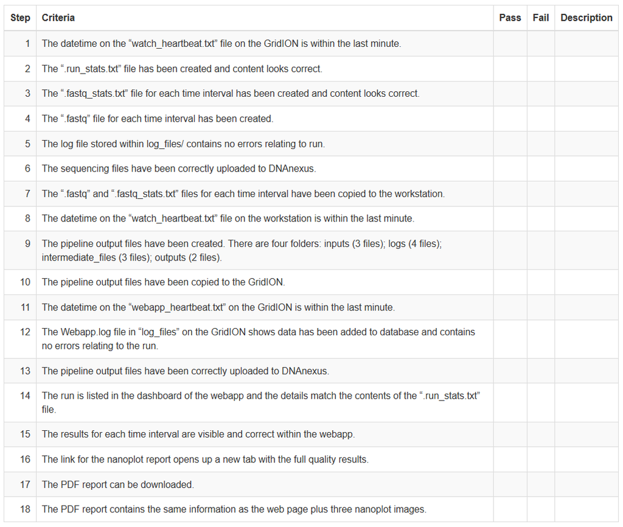

Table 1: Workflow testing criteria

### 3.2. Testing results

Workflow testing identified several issues across both the dummy and validation runs. There was an additional issue identified with the first live run which has also been added to the table.

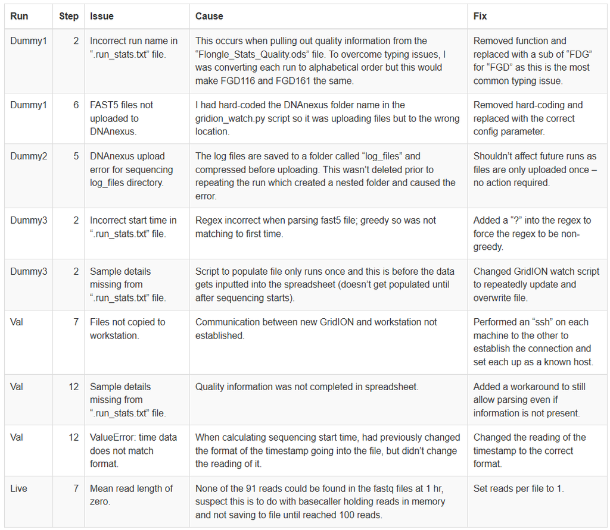

Table 2: Workflow testing errors

Additional general issues observed while performing the testing:

- GridION watch script continues to create “.run_stats.txt” file even after analysis is complete. This overwriting is needed during the analysis as the quality information does not get completed until after sequencing starts, but this code was moved to only run if the analysis is not complete.
- There was a database locked error in the webapp log files. This is error is caused by multiple instances trying to save to the database at any one time which is not possible with a SQLite database. So I added a file indicator to the script to ensure only one instance of the parsing script is run at once.